# Machine Learning - Prediction Assignment

Antonello Finucci

1/29/2018

# Introduction

This document contains the study performed for the Coursera Practical Machine Learning course using the data from the Weight Lifting Exercises Dataset (WLE) about the quality with which physical exercises are performed. The goal is to predict the way in which they did the exercise. The “quality” of the exercises is contained in the “classe” variable in the data set.

This document describe how the model, to solve the classification problem, using cross validation to reduce the expected out of sample error is built, together with a description about the choices made.

In this study three different machine learning algorithms are used:

1. the Linear Discriminant Analysis (LDA)
2. the Random Forest (RF)
3. the Decision Trees (C5.0)

A k-fold cross validation is used to improve the performances of the models. The performances of the models are assessed using the confusion matrix of the caret package.

The selected ML model is used to predict the results of a 20 samples test data set.

# Global settings

```r
            set.seed(123)
            library(caret)
```

```r
            library(corrplot)
            library(C50)
```

# Data preparation and analysis

The training data for this project are available here:

https://d396qusza40orc.cloudfront.net/predmachlearn/pml-training.csv

```r
          training <-  read.csv("https://d396qusza40orc.cloudfront.net/predmachlearn/pml-training.csv")
```

The test data are available here:

https://d396qusza40orc.cloudfront.net/predmachlearn/pml-testing.csv

```r
          testing <-  read.csv("https://d396qusza40orc.cloudfront.net/predmachlearn/pml-testing.csv")
```

The train data set contains 19622 observations and 160 variables.

The test data set contains 20 observations and 160 variables.

## Creating the training and testing data sets

For training the ML models 70% of the data are used for training and 30% for validation.

```r
          inTrain <- createDataPartition(y=training$classe, p=0.7, list = FALSE)

          train.data <- training[inTrain,]
          test.data <- training[-inTrain,]

          dim(train.data)
```

```
## [1] 13737   160
```

```r
          dim(test.data)
```

```
## [1] 5885  160
```

## Data set clean up

Due to the high number of variables further investigation are necessary to try to reduce their number.

First the variable with zero or near-zero variance can be removed because they are uninformative.

```r
          nzv <- nearZeroVar(training)
          train.data <- train.data[, -nzv]
          test.data <- test.data[, -nzv]

          dim(train.data)
```

```
## [1] 13737   100
```

```r
          dim(test.data)
```

```
## [1] 5885  100
```

Afterward all the columns containing an elevated percent of NAs are eliminated because they will have minor contribution to the outcomes.

```r
          NAindex    <- sapply(train.data, function(x) mean(is.na(x))) > 0.9
          train.data <- train.data[, NAindex==FALSE]
          test.data  <- test.data[, NAindex==FALSE]
          dim(train.data)
```

```
## [1] 13737    59
```

```r
          dim(test.data)
```

```
## [1] 5885   59
```

From a further analysis of the reduced data set it can be seen that the first 5 columns contains only Names, Timestamps, etc., and they could be also eliminated.

```r
          train.data <- train.data[,-c(1:5)]
          test.data <- test.data[,-c(1:5)]
          dim(train.data)
```

```
## [1] 13737    54
```

```r
          dim(test.data)
```

```
## [1] 5885   54
```

Another method to reduce the number of variables even further is to perform a Principal Components Analysis (PCA). This method is useful if the variables are correlated and allow to use a smaller set of variables that explain most of the variability of the original set.

Before to proceed with a PCA analysis a correlation matrix of the variables is used to check the numbers of variables correlated.

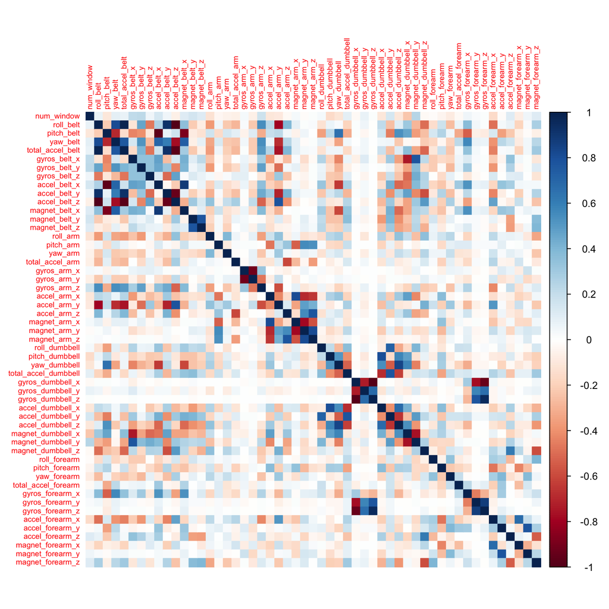

Figure 1 - Correlation Matrix

```r
          corMatrix <- cor(train.data[, -54])
          corrplot(corMatrix,  method = "color",tl.cex = 0.6)
```

As it can be seen from the Figure 1 the number of highly correlated variables is limited (dark colors) and for this reason a PCA analysis is not performed.

# Training the models using cross valivation

In the following a k-fold cross validation with k = 5 is used. If the accuracy of the models are not satisfactory a k =10 cv would be used.

## Linear Discriminant Analysis (LDA) model

```r
          ctrl_lda <- trainControl(method = "cv", number = 5)
          fit.lda <- train(classe ~. , method = "lda", data = train.data, trControl = ctrl_lda)

          prediction.lda <- predict(fit.lda, newdata = test.data)

          cm_lda <- confusionMatrix(prediction.lda, test.data$classe)
```

```r
          cm_lda
```

```
## Confusion Matrix and Statistics
##
##           Reference
## Prediction    A    B    C    D    E
##          A 1371  172  103   46   50
##          B   59  730  113   51  178
##          C  112  149  684  125   93
##          D  127   53  103  698   99
##          E    5   35   23   44  662
##
## Overall Statistics
##
##                Accuracy : 0.7043
##                  95% CI : (0.6925, 0.716)
##     No Information Rate : 0.2845
##     P-Value [Acc > NIR] : < 2.2e-16
##
##                   Kappa : 0.6258
##  Mcnemar's Test P-Value : < 2.2e-16
##
## Statistics by Class:
##
##                      Class: A Class: B Class: C Class: D Class: E
## Sensitivity            0.8190   0.6409   0.6667   0.7241   0.6118
## Specificity            0.9119   0.9155   0.9014   0.9224   0.9777
## Pos Pred Value         0.7870   0.6454   0.5881   0.6463   0.8609
## Neg Pred Value         0.9269   0.9140   0.9276   0.9446   0.9179
## Prevalence             0.2845   0.1935   0.1743   0.1638   0.1839
## Detection Rate         0.2330   0.1240   0.1162   0.1186   0.1125
## Detection Prevalence   0.2960   0.1922   0.1976   0.1835   0.1307
## Balanced Accuracy      0.8654   0.7782   0.7840   0.8232   0.7948
```

## Random Forest model

```r
          ctrl_rf <- trainControl(method = "cv", number = 5)
          fit.rf <- train(classe ~. , method = "rf", data = train.data, trControl = ctrl_rf)

          prediction.rf <- predict(fit.rf, newdata = test.data)

          cm_rf <- confusionMatrix(prediction.rf, test.data$classe)
```

```r
          cm_rf
```

```
## Confusion Matrix and Statistics
##
##           Reference
## Prediction    A    B    C    D    E
##          A 1674    2    0    0    0
##          B    0 1137    4    0    0
##          C    0    0 1022    2    0
##          D    0    0    0  961    0
##          E    0    0    0    1 1082
##
## Overall Statistics
##
##                Accuracy : 0.9985
##                  95% CI : (0.9971, 0.9993)
##     No Information Rate : 0.2845
##     P-Value [Acc > NIR] : < 2.2e-16
##
##                   Kappa : 0.9981
##  Mcnemar's Test P-Value : NA
##
## Statistics by Class:
##
##                      Class: A Class: B Class: C Class: D Class: E
## Sensitivity            1.0000   0.9982   0.9961   0.9969   1.0000
## Specificity            0.9995   0.9992   0.9996   1.0000   0.9998
## Pos Pred Value         0.9988   0.9965   0.9980   1.0000   0.9991
## Neg Pred Value         1.0000   0.9996   0.9992   0.9994   1.0000
## Prevalence             0.2845   0.1935   0.1743   0.1638   0.1839
## Detection Rate         0.2845   0.1932   0.1737   0.1633   0.1839
## Detection Prevalence   0.2848   0.1939   0.1740   0.1633   0.1840
## Balanced Accuracy      0.9998   0.9987   0.9978   0.9984   0.9999
```

## Training the C5.0 decision tree model

```r
          ctrl_rf <- trainControl(method = "cv", number = 5)

          fit.c50 <- train(classe ~. , method = "C5.0", data = train.data, trControl = ctrl_rf)

          prediction.c50 <- predict(fit.c50, newdata = test.data)

          cm_C50 <- confusionMatrix(prediction.c50, test.data$classe)
```

```r
          cm_C50
```

```
## Confusion Matrix and Statistics
##
##           Reference
## Prediction    A    B    C    D    E
##          A 1674    1    0    0    0
##          B    0 1138    2    0    0
##          C    0    0 1024    1    0
##          D    0    0    0  962    1
##          E    0    0    0    1 1081
##
## Overall Statistics
##
##                Accuracy : 0.999
##                  95% CI : (0.9978, 0.9996)
##     No Information Rate : 0.2845
##     P-Value [Acc > NIR] : < 2.2e-16
##
##                   Kappa : 0.9987
##  Mcnemar's Test P-Value : NA
##
## Statistics by Class:
##
##                      Class: A Class: B Class: C Class: D Class: E
## Sensitivity            1.0000   0.9991   0.9981   0.9979   0.9991
## Specificity            0.9998   0.9996   0.9998   0.9998   0.9998
## Pos Pred Value         0.9994   0.9982   0.9990   0.9990   0.9991
## Neg Pred Value         1.0000   0.9998   0.9996   0.9996   0.9998
## Prevalence             0.2845   0.1935   0.1743   0.1638   0.1839
## Detection Rate         0.2845   0.1934   0.1740   0.1635   0.1837
## Detection Prevalence   0.2846   0.1937   0.1742   0.1636   0.1839
## Balanced Accuracy      0.9999   0.9994   0.9989   0.9989   0.9994
```

# Final model selection

```r
          accuracy_data <- data.frame(method =c ("lda", "rf", "c50"),
                                      accuracy = c(round(cm_lda$overall[1], 3),
                                      round(cm_rf$overall[1], 3),
                                      round(cm_C50$overall[1],3)))
          accuracy_data
```

```
##   method accuracy
## 1    lda    0.704
## 2     rf    0.998
## 3    c50    0.999
```

From the table above it can be seen that the C5.0 model is the one having the best accuracy and it is the one selected to predict the test data set.

# Predicting the test data set

To complete the project the selected model, the c5.0 model, is used to predict the “classe” of the unseen data contained in the “testing” data set.

```r
          predict_testing <- predict(fit.c50, testing)

          predict_testing
```

```
##  [1] B A B A A E D B A A B C B A E E A B B B
## Levels: A B C D E
```